# Homework#1

## Assignment#1

### IE360 Spring-22

Yasin Secal 2018402135

**Aim**

To see whether *saving* and *borrowing* money habits of Turkish people are affected by *USD/TRY rate* and *interest rate* it is denoted in EVDS as *Consumer Loan*.

Also, checking whether there is a corrolation between *zam* search in Google and *saving* and *borrowing* money habits.

**Data Sources Used for Assignment**

1-) Electronic Data Delivery System

- Surveys / Probability of saving money
- Surveys / Probability of borrowing money
- Exchange rates / USD/TRY rate
- Interest Statistics / Consumer Loan

2-) Google Trends

- "zam" search in Turkey

### Data Preparation

#### Libraries

```python
import pandas as pd
import seaborn as sns
import matplotlib.pyplot as plt
import numpy as np
```

#### Data Source Uploading

Two files called. The first is indicating EVDS platform the other is Google Trends. Please find them in my journal.

```python
# Data uploading part
data=pd.read_excel("C:/Users/SEY9IB/database/original_data.xlsx") # EVDS data
data1=pd.read_csv("C:/Users/SEY9IB/database/multiTimeline.csv") # Google Trends data
```

#### Data Manipulation

```python
# Preparation data
data.Date=pd.to_datetime(data.Date,format="%Y-%m")
data=data[data.Date.dt.year>=2014]

# Preparation data1
data1.rename(columns={"Month":"Date", "zam: (Turkey)":"zam"}, inplace=True)
data1.Date=pd.to_datetime(data1.Date,format="%Y-%m")
data1=data1[data1.Date.dt.year>=2014]
data1.reset_index(drop=True,inplace=True)
```

In code part above data used after 2014 because it is obvious that for financial statistics of Turkey are changed very fast after that date. I want to compare today's current picture with more similar data. It is the same for Google Trends search. Also, it is obivous that technology consumption is exponentially growing and more data is available recent dates, so I prefer data after 2014.

As seen above Date columns are adjusted on year-month base. Then, My datasets are ready to further.

#### Merging Data and Data1

```python
# Merging datasets
merged=data.merge(data1,how="inner",on="Date")
merged.dropna(inplace=True)
merged.head()
```

|  | Date | USD/TRY | Consumer Loan | The probability of saving | The probability of borrowing money | zam |
| --- | --- | --- | --- | --- | --- | --- |
| 0 | 2014-01-01 | 2.218841 | 13.5140 | 26.102034 | 39.873300 | 13 |
| 1 | 2014-02-01 | 2.214752 | 15.4575 | 21.985950 | 39.035450 | 6 |
| 2 | 2014-03-01 | 2.219790 | 15.8900 | 24.098460 | 37.210442 | 4 |
| 3 | 2014-04-01 | 2.129383 | 15.8625 | 26.608840 | 37.137178 | 6 |
| 4 | 2014-05-01 | 2.092685 | 15.4280 | 26.599285 | 38.826719 | 4 |

### Data Visualization

#### Comparison of Borrowing and Saving Money Habits

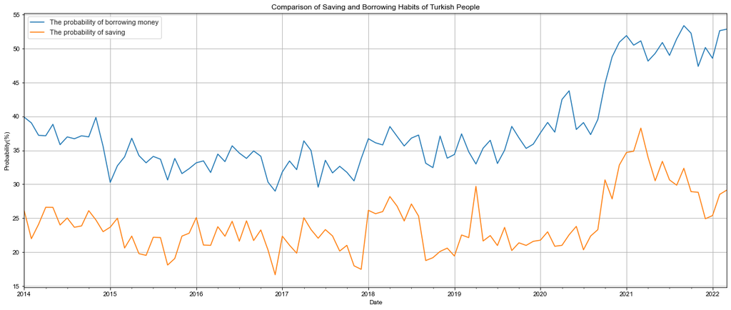

```python
fig, ax = plt.subplots()
fig.set_size_inches(20,8)

sns.set(style="whitegrid")
data.plot(x="Date",y=["The probability of borrowing money","The probability of saving"],ax=ax)
ax.set_title("Comparison of Saving and Borrowing Habits of Turkish People")
ax.set_xlabel("Date")
ax.set_ylabel("Probability(%)")
plt.show()
```

First milestone is having a look to target attributes. As seen graph above probability of borrowing money and saving money have a relationship. When I decided to search saving money and borrowing money probabilities I was expecting that they are negatively correlated. However, I was wrong they seem to have positive correlation. When discussing seperately *Borrowing Money* trend tends to be increasing in recent 2-3 years. Also, I could not realize any obvious seasonality in this graph. On the other hand, *Saving Money* trend seems to be distributed around 22.5% and an increase observed in 2021. Also, it does not show any seasonality,too. Maybe, checking autocorrelation graphs gives more better result for seasonality.

In further sections, comparison of these 2 attributes with other attriubes will be visualized.

#### Yearly Graphs of the Attributes ( Saving and Borrowing Money)

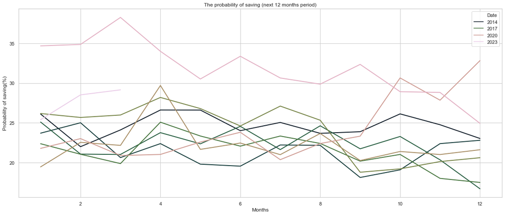

```python
fig, ax = plt.subplots()
fig.set_size_inches(20,8)

sns.set(style="whitegrid")
sns.lineplot(data=data,x=data.Date.dt.month,y="The probability of saving",palette="ch:r=-1,d=.1_r",hue=data.Date.dt.year,linewidth=2, ax=ax)
ax.set_title("The probability of saving (next 12 months period)")
ax.set_xlabel("Months")
ax.set_ylabel("Probability of saving(%)")
plt.show()
```

As seen above graph shows monthly distribution of *Probability of saving money* of each year between 2014 and 2022. years are indicated by colors dark green to light pink in ascending order. It can be understood from legend.

**Note :** there is a half line and it shows 2022.

When having a look I could not realize any obvious seasonlity. I am seeing sharp increases in March, April and October months. Also, Saving habits tend to increase towards to recent years. These are all take-aways from this graph because it seems to be randomly distributed.

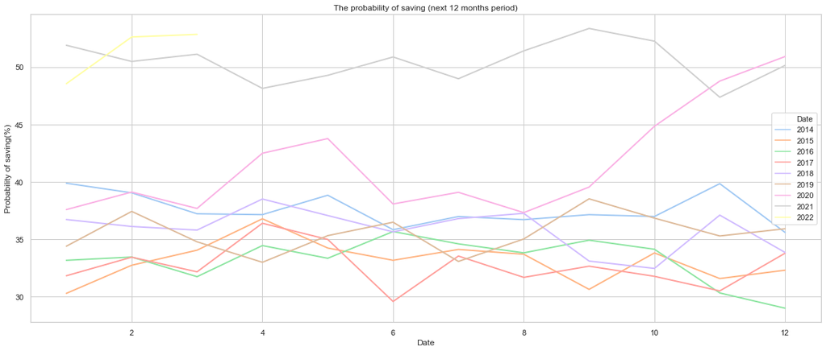

```python
fig, ax = plt.subplots()
fig.set_size_inches(20,8)

sns.set(style="whitegrid")
sns.lineplot(data=data,x=data.Date.dt.month,y="The probability of borrowing money",palette="pastel",linewidth=2,hue=data.Date.dt.year, ax=ax)
ax.set_title("The probability of saving (next 12 months period)")
ax.set_xlabel("Date")
ax.set_ylabel("Probability of saving(%)")
plt.show()
```

Again, it is hard to see any seasonality in this graph. I can only say that the trend is increasing towards to 2022. Therefore, I think that *borrowing money* has more explainable relationship with *USD* exchange rate, *Consumer Loan*, and *zam* searching amount. Let's check this claim in further graphs.

In a nutshell, we know that USD exchange rates and consumer interest rates have increasing trends in the periods between 2014 and 2022. Therefore, I believe that these have positive correlation with *probability of borrowing money*.

#### Autocorrelation Graphs

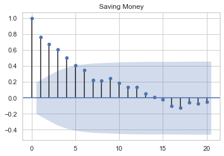

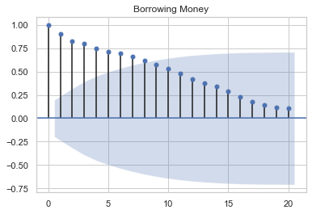

```python
from statsmodels.graphics.tsaplots import plot_acf

plot_acf(data["The probability of saving"],title="Saving Money")
plt.show()

plot_acf(data["The probability of borrowing money"],title="Borrowing Money")
plt.show()
```

The main goal to plot autocorrelation function is to see whether they have any seasonal patterns that I could not realize. However, as assumed they don't exhibit any seasonal pattern.

#### Graphs for USD/TRY Rates, Consumer Loan, and "Zam" Searches

#### USD/TRY Rates

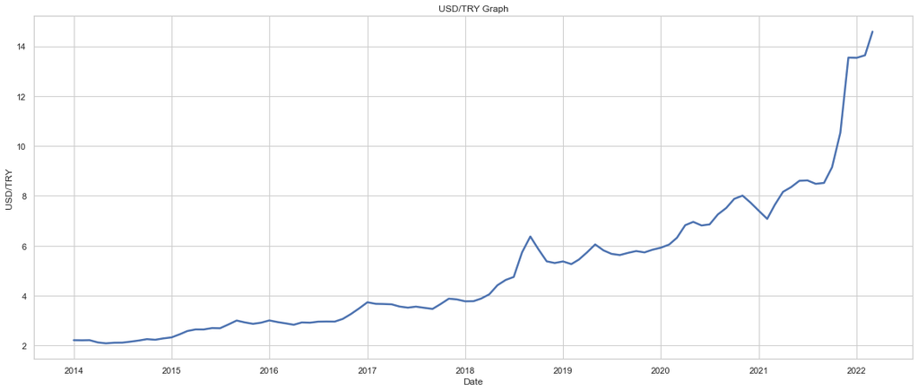

```python
fig, ax = plt.subplots()
fig.set_size_inches(20,8)

sns.set(style="whitegrid")
sns.lineplot(data=merged,x="Date",y="USD/TRY", linewidth=2.5, ax=ax)
ax.set_title("USD/TRY Graph")
ax.set_xlabel("Date")
ax.set_ylabel("USD/TRY")
plt.show()
```

As seen above USD rate tends to increase. There is no need to discuss why it is increasing because underlying effects are related with politic topics.

#### Consumer Loan Interest Rates

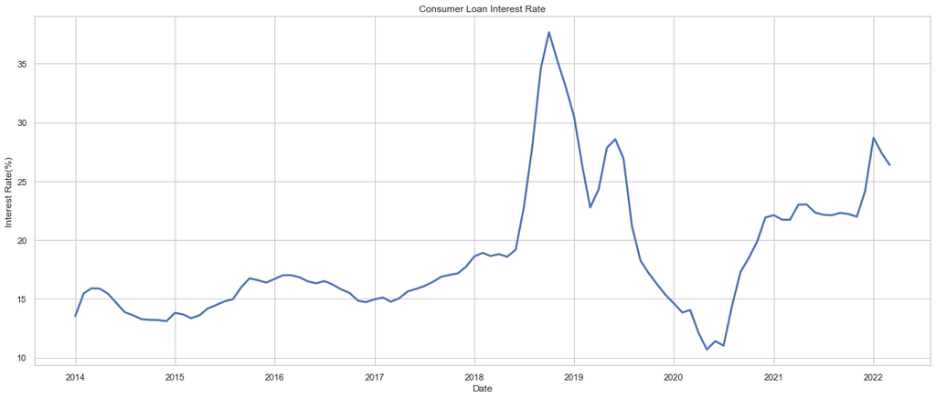

```python
fig, ax = plt.subplots()
fig.set_size_inches(20,8)

sns.set(style="whitegrid")
sns.lineplot(data=merged,x="Date",y="Consumer Loan", linewidth=2.5, ax=ax)
ax.set_title("Consumer Loan Interest Rate")
ax.set_xlabel("Date")
ax.set_ylabel("Interest Rate(%)")
plt.show()
```

It is same for *Consumer Loan* rate. However, there is no obvious trend or seasonality.

#### 'Zam' Searches

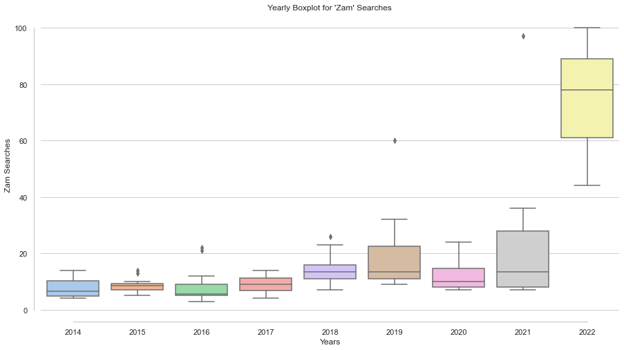

```python
fig, ax = plt.subplots()
fig.set_size_inches(15,8)

sns.set(style="whitegrid")
sns.boxplot(x=merged.Date.dt.year, y="zam",palette="pastel",data=merged,ax=ax)
sns.despine(offset=10, trim=True)
ax.set_title(" Yearly Boxplot for 'Zam' Searches ")
ax.set_xlabel("Years")
ax.set_ylabel("Zam Searches")
plt.show()
```

I prefer box-plot to show "zam" searches, because as seen zam data it does not significant changes between 2014 and 2018. It is obvious in my graph,too. Also, there is no resoanable variablity. On the other hand, in the recent years variability has increased. Maybe, having a look to line plot can be better.

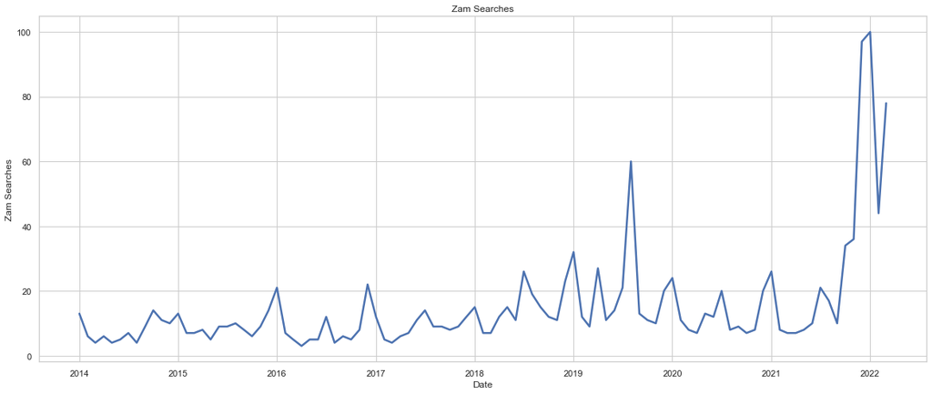

```python
fig, ax = plt.subplots()
fig.set_size_inches(20,8)

sns.set(style="whitegrid")
sns.lineplot(data=merged,x="Date",y="zam", linewidth=2.5, ax=ax)
ax.set_title("Zam Searches")
ax.set_xlabel("Date")
ax.set_ylabel("Zam Searches")
plt.show()
```

### Comparision of Attributes

#### Overview

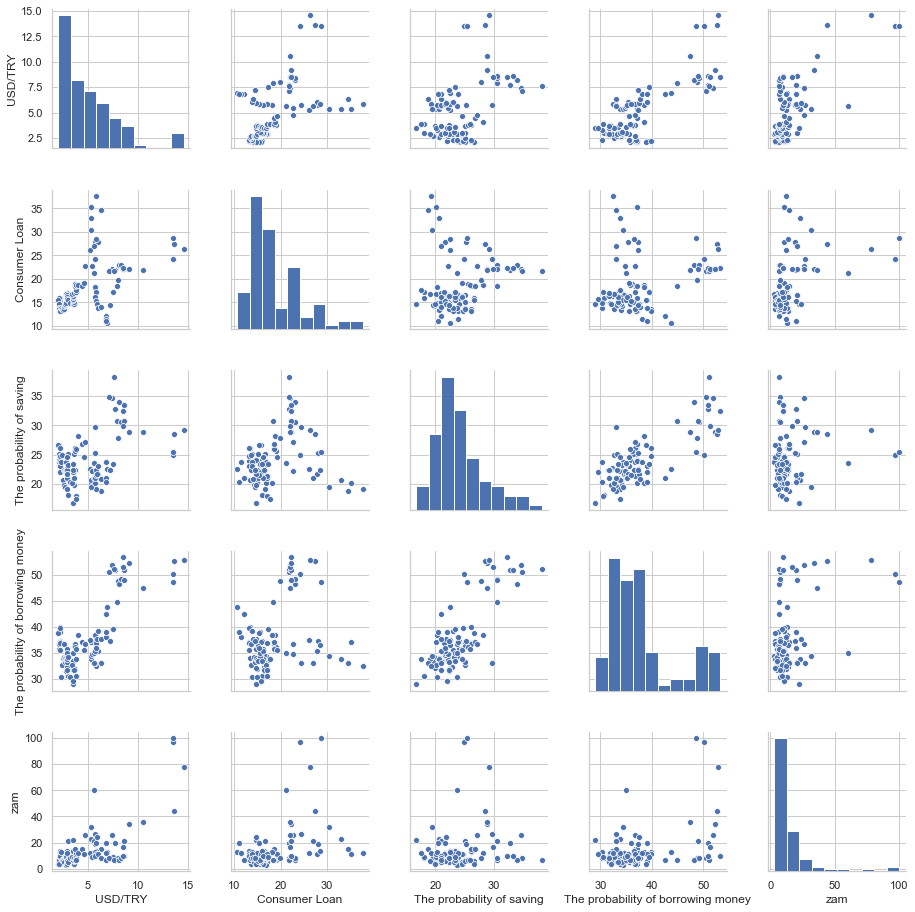

```python
sns.set(style="whitegrid")
sns.pairplot(merged)
plt.show()
```

In this part, I created all possible scatter plot for comparing the all attributes. When having an overlook I realized that **Borrowing Money**&**Saving Money**, **Borrowing Money**&**USD/TRY rates**, and **zam**&**USD/TRY rates** have a significant relationship. They will be investigated in further graphs. Also, even if **Consumer loan** and **zam** have some noisy points they seem a linear relationship with small slope. Maybe, creating a graph for them can be better.

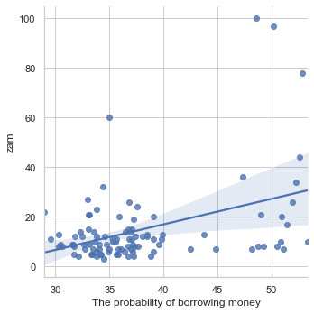

```python
sns.lmplot(y="zam",x="The probability of borrowing money", data=merged)
plt.show()
```

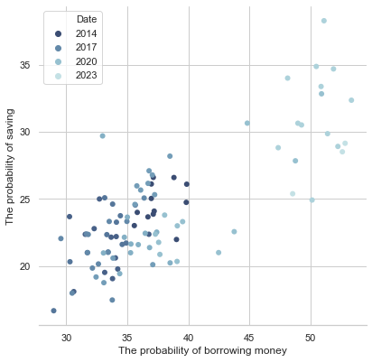

```python
sns.set(style="whitegrid")
f, ax = plt.subplots(figsize=(6.5, 6.5))
sns.despine(f, left=True, bottom=False)
sns.scatterplot(x="The probability of borrowing money",y="The probability of saving",hue=data.Date.dt.year,
                data=data,palette="ch:r=-.2,d=.3_r", linewidth=0,ax=ax,sizes=(1, 8))
plt.show()
```

For this comparison I prefered this graph type because I already know that they are highly correlated. It is obvious that towards to recent years both probability of borrowing money and saving has increased. As mentioned previous it is unexpected situation because why a person needs to borrow money when decided to save his/her money.

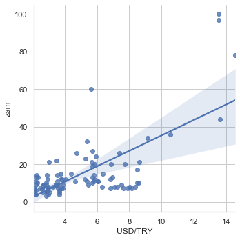

```python
sns.lmplot(y="zam",x="USD/TRY", data=merged)
plt.show()
```

This graph demonstrates that dollar and zam has important relationship. Also, slope of line tells us that any change in dollar will cause significant increase or decrease in "zam" searches. On the other hand, the correlation is not reliable a lot because variability is higher.

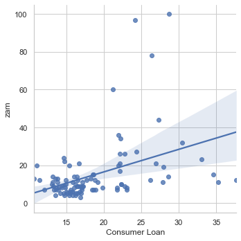

```python
sns.lmplot(y="zam",x="Consumer Loan", data=merged)
plt.show()
```

This relationship is not important as much as previous relationship in previous graphs, but if nosiy points are removed, the correlation should increase.

### Conclusion-Part

#### Correlation Matrix & Heatmap Creation

```python
# Correlation Function called.
correlation=merged.corr()
```

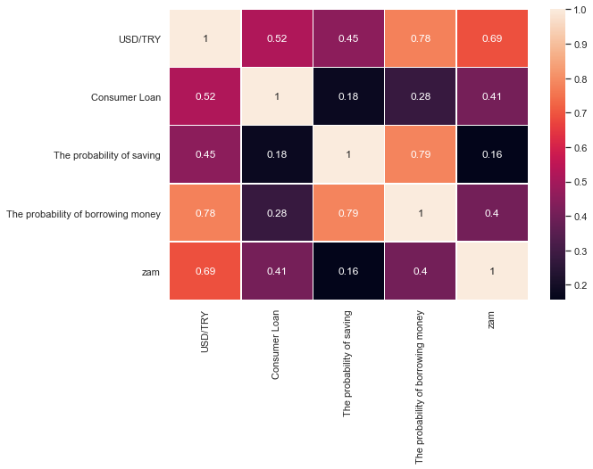

```python
# Heatmap used because it is better for visual representation.
sns.set(palette="pastel")
f, ax = plt.subplots(figsize=(9, 6))
sns.heatmap(correlation, annot=True, linewidths=.5, ax=ax)
plt.show()
```

Before my last words I am looking the correlation matrix because I have chance to see whether I missed any relationship to discuss. Hopefully, there is no further points to discuss. As seen in the heatmap all relationships are covered in previous section. Also, it is unexpected situation that **the probability of saving** has no significant relationship with **Consumer Loan** and **zam**. Let's go to conclusion part.

#### Last Words

When starting to the analysis I was expecting **Probability of borrowing money** and **Probability of saving** has negative correlation because saving seems positive action and borrowing seems negative action. On the contrary, they have positive correlation. After comparing both of them I saw that **Probability of borrowing money** has more meaning than the other. Therefore, I prefered to only compare borrowing money habits with *zam*,*USD/TRY*, and *Consumer Loan*. Not surprisingly, people consider borrowing money when dollar increase. However, Interest rate(Consumer Loan Rate) has not effect on borrowing money habits as much as dollar has.

Also, when idea of borrowing money increase "zam" searches on google increase, because both of them are highly correlated with dollar rate.